# Wholesale customers analysis

Dataset - https://archive.ics.uci.edu/ml/datasets/wholesale+customers

## 1. Data

```python
# Uncomment below lines for first run only
#import sys
#!{sys.executable} -m pip install numpy pandas sklearn matplotlib pyclustertend seaborn

import pandas as pd
import numpy as np
from sklearn import preprocessing
from sklearn.decomposition import PCA
import matplotlib.pyplot as plt
from pyclustertend import hopkins
from sklearn.cluster import KMeans
from sklearn.metrics import silhouette_score
import seaborn as sb
from sklearn.cluster import AgglomerativeClustering
from scipy.cluster.hierarchy import dendrogram, linkage
from sklearn.cluster import DBSCAN

# Importing data from csv
customers_df = pd.read_csv("data/wholesale_customers_data.csv")

# Remove nominal attributes CHANNEL and REGION
org_data = customers_df.drop(columns=['Channel', 'Region'])
print("\n>>> Nominal attribtues - Channel and Region Removed\n")
print(org_data)
```

```
>>> Nominal attribtues - Channel and Region Removed

     Fresh   Milk  Grocery  Frozen  Detergents_Paper  Delicassen
0    12669   9656     7561     214              2674        1338
1     7057   9810     9568    1762              3293        1776
2     6353   8808     7684    2405              3516        7844
3    13265   1196     4221    6404               507        1788
4    22615   5410     7198    3915              1777        5185
..     ...    ...      ...     ...               ...         ...
435  29703  12051    16027   13135               182        2204
436  39228   1431      764    4510                93        2346
437  14531  15488    30243     437             14841        1867
438  10290   1981     2232    1038               168        2125
439   2787   1698     2510      65               477          52

[440 rows x 6 columns]
```

## 2. Data Exploration

```python
# gets min,max,mean,standard deviation from org_data rounded to 2 decimal places
round(org_data[['Fresh','Milk','Grocery','Frozen','Detergents_Paper','Delicassen']].describe(),2)
```

|  | Fresh | Milk | Grocery | Frozen | Detergents_Paper | Delicassen |
| --- | --- | --- | --- | --- | --- | --- |
| count | 440.00 | 440.00 | 440.00 | 440.00 | 440.00 | 440.00 |
| mean | 12000.30 | 5796.27 | 7951.28 | 3071.93 | 2881.49 | 1524.87 |
| std | 12647.33 | 7380.38 | 9503.16 | 4854.67 | 4767.85 | 2820.11 |
| min | 3.00 | 55.00 | 3.00 | 25.00 | 3.00 | 3.00 |
| 25% | 3127.75 | 1533.00 | 2153.00 | 742.25 | 256.75 | 408.25 |
| 50% | 8504.00 | 3627.00 | 4755.50 | 1526.00 | 816.50 | 965.50 |
| 75% | 16933.75 | 7190.25 | 10655.75 | 3554.25 | 3922.00 | 1820.25 |
| max | 112151.00 | 73498.00 | 92780.00 | 60869.00 | 40827.00 | 47943.00 |

## 3. Data Transformation I (Standardization)

```python
def standardize_data(data):

    col_names = data.columns
    # calls standardization function z = (x - u) / s
    scaler = preprocessing.StandardScaler()
    # fits data and transforms
    standardized_df = scaler.fit_transform(data)
    # convert to dataframe with column names
    standardized_org_data = pd.DataFrame(standardized_df, columns=col_names)
    return standardized_org_data

trans_data = standardize_data(org_data)

# printing the first 10 rows
print(trans_data.head(10))
```

```
      Fresh      Milk   Grocery    Frozen  Detergents_Paper  Delicassen
0  0.052933  0.523568 -0.041115 -0.589367         -0.043569   -0.066339
1 -0.391302  0.544458  0.170318 -0.270136          0.086407    0.089151
2 -0.447029  0.408538 -0.028157 -0.137536          0.133232    2.243293
3  0.100111 -0.624020 -0.392977  0.687144         -0.498588    0.093411
4  0.840239 -0.052396 -0.079356  0.173859         -0.231918    1.299347
5 -0.204806  0.334067 -0.297637 -0.496155         -0.228138   -0.026224
6  0.009950 -0.352316 -0.102849 -0.534512          0.054280   -0.347854
7 -0.349981 -0.113981  0.155359 -0.289315          0.092286    0.369601
8 -0.477901 -0.291409 -0.185336 -0.545854         -0.244726   -0.275079
9 -0.474497  0.718495  1.151423 -0.394488          0.954031    0.203461
```

## 4. Data Transformation II (Dimensionality Reduction)

```python
def dimensionality_reduction(stzd_data,cmpnts):
    pca = PCA(n_components=cmpnts)
    pca_components = pca.fit_transform(stzd_data)
    pca_org_data = pd.DataFrame(pca_components, columns=['PC1','PC2'])
    return pca, pca_org_data

'''
no_of_components can be chosen as 'mle' which uses the
method of Minka, T. P. “Automatic choice of dimensionality for PCA”. In NIPS, pp. 598-604
'''

# conduct pca on trans_data with no_of_components = 2
pca, reduced_data = dimensionality_reduction(trans_data, 2)

# printing the first 10 rows
print(reduced_data.head(10))

# Percentage of variance explained by each of the selected components.
var_percent = pca.explained_variance_ratio_

# Percentage of total variance represented by PC1 and PC2
print("\nPercentage of total variance represented by PC1 & PC2 = {}%".format(((var_percent[0]+var_percent[1])*100).round(2)))
```

```
        PC1       PC2
0  0.193291 -0.305100
1  0.434420 -0.328413
2  0.811143  0.815096
3 -0.778648  0.652754
4  0.166287  1.271434
5 -0.156170 -0.295141
6 -0.335288 -0.525003
7  0.140586 -0.230993
8 -0.517320 -0.659363
9  1.592109 -0.741011

Percentage of total variance represented by PC1 & PC2 = 72.46%
```

## 5. Data Visualization

### 5.1 Plot original features with principal components in reduced_data with 2 features (dimensions)

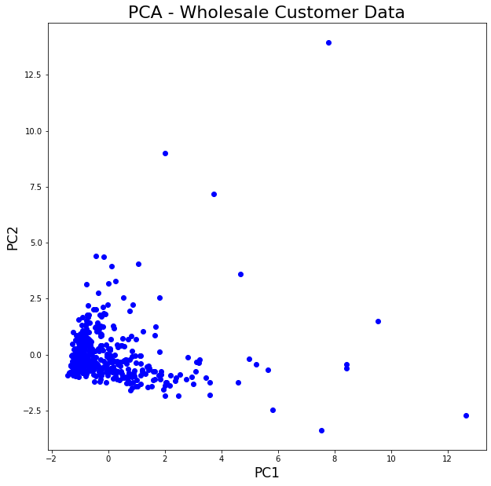

```python
figure = plt.figure(figsize = (10,10))
plot = figure.add_subplot(1,1,1)
plot.set_xlabel('PC1', fontsize = 17)
plot.set_ylabel('PC2', fontsize = 17)
plot.set_title('PCA - Wholesale Customer Data', fontsize = 22)
plot.scatter(reduced_data['PC1'], reduced_data['PC2'], c='blue')
```

### 5.2 Can you find any cluster tendency visually?

Yes, we observe a cluster tendency after plotting the principal components (PC1 vs PC2)

## 6. Cluster tendency

### 6.1 Compute Hopkins statistic

```python
# Compute the Hopkins statistic with 440 sampling size
hopkins_statistic = hopkins(trans_data,440).round(3)
print("Hopkins Statistic = {}".format(hopkins_statistic))
```

```
Hopkins Statistic = 0.064
```

### 6.2 Does warehouse customer data show useful clustering tendencies using the Hopkins statistic value?

The Hopkins statistic test is the assessment of the clusterability of a dataset. The range for Hopkins statistic is 0≤x≤1. A value around 0.5 express no clusterability and a score tending to 0 express a high cluster tendency.

```python
print("Our dataset shows a value of {} which clearly indicates high cluster tendency!".format(hopkins_statistic))
```

```
Our dataset shows a value of 0.064 which clearly indicates high cluster tendency!
```

## 7. Optimal number of clusters (k)

### 7.1 Elbow method

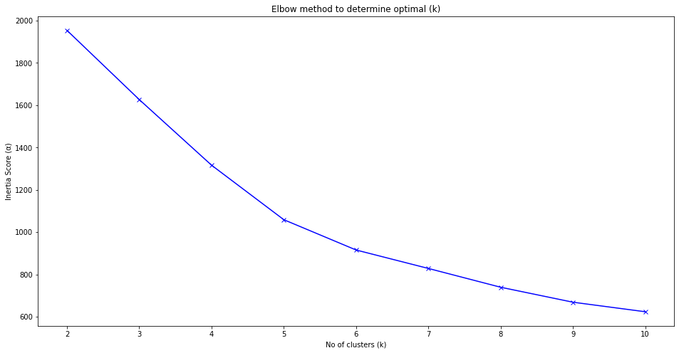

```python
#Identify optimal clusters(k)

#Elbow method
score = []

# We begin with a minimum number of clusters of atleast 2
K = range(2,11)

for k in K:
    kmeanModel = KMeans(n_clusters=k)
    kmeanModel.fit(trans_data)
    # Inertia: It is the sum of squared distances of samples to their closest cluster center.
    score.append(kmeanModel.inertia_)

# Displays the sum of squared distance to its closest cluster.
#print("Inertia Score (α)\n")
#for x in score:
#    print(round(x,2))
#print("\n")

plt.figure(figsize=(16,8))
plt.plot(K, score, 'bx-')
plt.xlabel('No of clusters (k)')
plt.ylabel('Inertia Score (α)')
plt.title('Elbow method to determine optimal (k)')
plt.show()
```

The elbow method helps to choose the optimum value of k (number of clusters) by fitting the model with a range of values of k. Let us start by understanding the cost function of K-means clustering. We define cost function of K-means clustering as 'Inertia Score (α)' which is sum of squares of distance of data point to their closest cluster. We can see that the cost function decreases with number of iterations/clusters (k).

The above shows figure shows a plot of No of clusters (k) vs Inertia Score (α).

**Therefore, we determine that elbow formation takes place at k=5(optimal), although it is not a very sharp elbow formation.**

### 7.2 Silhouette method

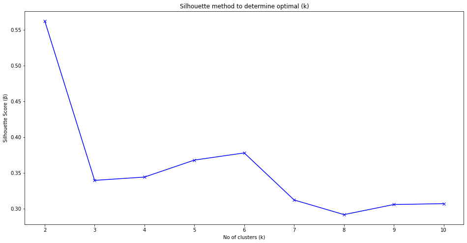

```python
sil = []
K = range(2,11)

# We begin with a minimum number of clusters of atleast 2
for k in K:
    kmeans = KMeans(n_clusters = k).fit(trans_data)
    # Predict the closest cluster each sample in X belongs to.
    predict = kmeans.predict(trans_data)
    sil.append(silhouette_score(trans_data,predict))

# Displays the silhouette score
#print("Silhouette Score (β)\n")
#for x in sil:
#    print(round(x,2))
#print("\n")

plt.figure(figsize=(16,8))
plt.plot(K, sil, 'bx-')
plt.xlabel('No of clusters (k)')
plt.ylabel('Silhouette Score (β)')
plt.title('Silhouette method to determine optimal (k)')
plt.show()
```

The silhouette score varies between -1≤β≤1. A value close to 1 implies that the instance is close to its cluster is a part of the right cluster. Whereas, a value close to -1 means that the value is assigned to the incorrect cluster. The Silhouette coefficient is calculated using the mean intra-cluster distance x and the mean nearest-cluster distance y for each data point.

The Silhouette Coefficient is defined as (y - x) / max(x, y). Silhouette method shows a peak characteristic whereas the Elbow method shows a slight bend, appearing like the formation of hand with the elbow being the point of bend. The silhouette method reaches its global maximum at the optimal k.

**Therefore, from our plot we can deduce that optimal k=2 from the Silhouette method.**

## 8. Representative-based clustering

```python
# Cluster analysis using kmeans k=6
total_sse=0
K = range(2,7)

# Representatives of each cluster (coordinates of cluster center)
print("\n>>> Representative of each cluster\n")
for k in K:
    kmeans = KMeans(n_clusters=k).fit(trans_data)
    print("\nK = {}\n".format(k))
    print(np.round(kmeans.cluster_centers_,3))

# SSE for each cluster k
print("\n\n>>> SSE of each cluster\n")
for k in K:
    kmeans = KMeans(n_clusters=k).fit(trans_data)
    print("K = {} | SSE = {}".format(k,round(kmeans.inertia_,2)))
    total_sse+=kmeans.inertia_

# Total SSE
print("\nTotal SSE = {}".format(round(total_sse,2)))
```

```
>>> Representative of each cluster


K = 2

[[-0.022  1.909  2.07   0.271  1.957  0.781]
 [ 0.003 -0.239 -0.259 -0.034 -0.245 -0.098]]

K = 3

[[ 1.233  4.043  3.717  0.851  3.604  2.45 ]
 [ 0.117 -0.346 -0.423  0.081 -0.418 -0.118]
 [-0.501  0.603  0.876 -0.346  0.875  0.083]]

K = 4

[[ 1.58  -0.127 -0.23   1.036 -0.403  0.331]
 [-0.292  1.853  2.225 -0.242  2.257  0.261]
 [-0.301 -0.233 -0.248 -0.208 -0.21  -0.155]
 [ 1.967  5.176  1.287  6.901 -0.555 16.478]]

K = 5

[[ 1.6590e+00 -1.0800e-01 -2.1800e-01  1.1030e+00 -4.0500e-01  3.3300e-01]
 [-4.9400e-01  6.8800e-01  9.1200e-01 -3.3200e-01  9.0700e-01  1.0200e-01]
 [-2.3000e-01 -3.8400e-01 -4.3700e-01 -1.6500e-01 -3.9700e-01 -1.9400e-01]
 [ 1.9670e+00  5.1760e+00  1.2870e+00  6.9010e+00 -5.5500e-01  1.6478e+01]
 [ 3.1400e-01  3.9220e+00  4.2760e+00 -4.0000e-03  4.6180e+00  5.0300e-01]]

K = 6

[[-2.1200e-01 -3.8500e-01 -4.4100e-01 -8.3000e-02 -4.0600e-01 -1.9000e-01]
 [ 3.8900e-01  3.9430e+00  4.0220e+00  3.6000e-02  4.2260e+00  9.4200e-01]
 [ 1.9670e+00  5.1760e+00  1.2870e+00  6.9010e+00 -5.5500e-01  1.6478e+01]
 [ 2.0560e+00 -7.5000e-02 -2.0700e-01  6.0700e-01 -3.9700e-01  2.9900e-01]
 [-5.0400e-01  6.2700e-01  8.9400e-01 -3.3200e-01  8.9400e-01  9.9000e-02]
 [ 7.9300e-01  5.6200e-01 -1.1000e-02  9.2530e+00 -4.6400e-01  9.3300e-01]]


>>> SSE of each cluster

K = 2 | SSE = 1954.04
K = 3 | SSE = 1614.52
K = 4 | SSE = 1325.98
K = 5 | SSE = 1058.77
K = 6 | SSE = 915.49

Total SSE = 6868.8
```

## 9. Visualization of clusters I

```
        PC1       PC2  Category
0  0.193291 -0.305100         3
1  0.434420 -0.328413         3
2  0.811143  0.815096         2
3 -0.778648  0.652754         0
4  0.166287  1.271434         2
5 -0.156170 -0.295141         0
6 -0.335288 -0.525003         0
7  0.140586 -0.230993         3
8 -0.517320 -0.659363         0
9  1.592109 -0.741011         3
```

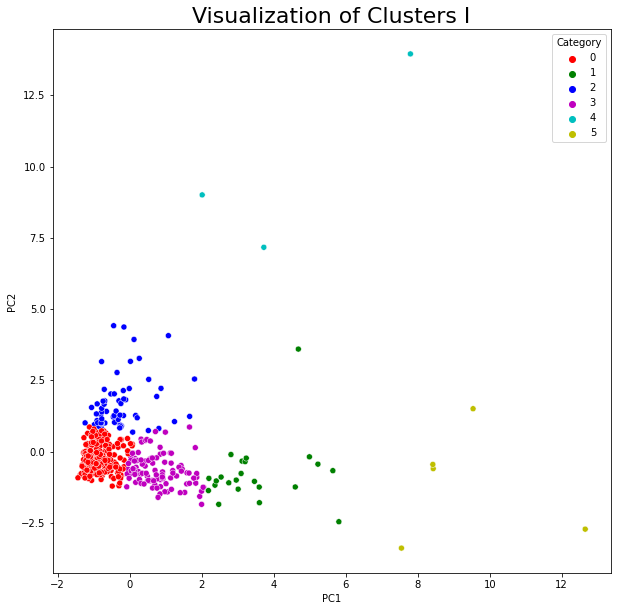

```python
# visualize using reduced_data and kmeans labels with k=6
visualize_data = reduced_data

kmeans = KMeans(n_clusters=6).fit(visualize_data)

visualize_data['Category'] = kmeans.labels_

# example of first 10 rows with category labels from kmeans
print(visualize_data.head(10))
print("\n")

# plotting PC1 vs PC2 to show clustering
figure = plt.figure(figsize = (10,10))
plot = figure.add_subplot(1,1,1)
sb.scatterplot(x = visualize_data['PC1'],y = visualize_data['PC2'],hue=visualize_data['Category'],palette=['r','g','b','m','c','y'])
plot.set_title('Visualization of Clusters I', fontsize = 22)
```

## 10. Hierarchical clustering

### 10.1 Single link agglomerative

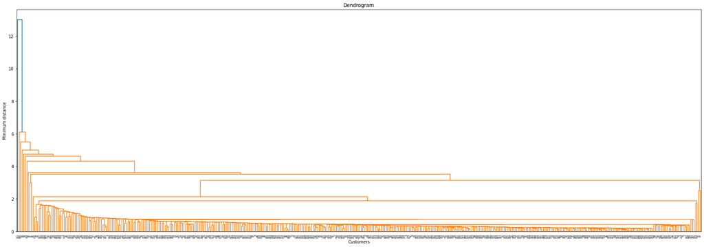

```python
# single linkage cluster dendogram
link = linkage(trans_data, method = 'single')
fig = plt.figure(figsize=(30, 10))
plt.title('Dendrogram')
plt.xlabel('Customers')
plt.ylabel('Minimum distance')
dn = dendrogram(link)
plt.show()
```

### 10.2 Complete link agglomerative

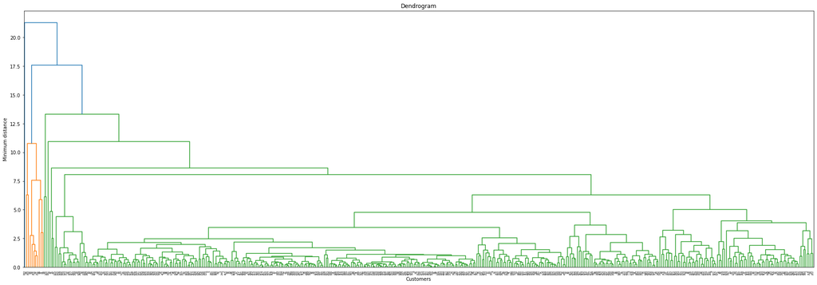

```python
# complete linkage cluster dendogram
link = linkage(trans_data, method = 'complete')
fig = plt.figure(figsize=(30, 10))
plt.title('Dendrogram')
plt.xlabel('Customers')
plt.ylabel('Minimum distance')
dn = dendrogram(link)
plt.show()
```

### 10.3 Plot complete link hierarchical clustering result

```
        PC1       PC2  Category
0  0.193291 -0.305100         0
1  0.434420 -0.328413         0
2  0.811143  0.815096         0
3 -0.778648  0.652754         0
4  0.166287  1.271434         0
5 -0.156170 -0.295141         0
6 -0.335288 -0.525003         0
7  0.140586 -0.230993         0
8 -0.517320 -0.659363         0
9  1.592109 -0.741011         0
```

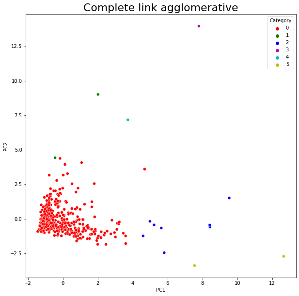

```python
# complete linkage agglomerative clustering
hc_cla = AgglomerativeClustering(n_clusters=6, linkage='complete').fit(trans_data)

cla_data = reduced_data
cla_data['Category'] = hc_cla.labels_

# showing first 10 rows of reduced_data with clustering labels
print(cla_data.head(10))

# plotting PC1 vs PC2 to show clustering
figure = plt.figure(figsize = (10,10))
plot = figure.add_subplot(1,1,1)
sb.scatterplot(x = cla_data['PC1'],y = cla_data['PC2'],hue=cla_data['Category'],palette=['r','g','b','m','c','y'])
plot.set_title('Complete link agglomerative', fontsize = 22)
```

## 11. Density-based clustering

```
        PC1       PC2  Category
0  0.193291 -0.305100        -1
1  0.434420 -0.328413        -1
2  0.811143  0.815096        -1
3 -0.778648  0.652754        -1
4  0.166287  1.271434        -1
5 -0.156170 -0.295141        -1
6 -0.335288 -0.525003        -1
7  0.140586 -0.230993        -1
8 -0.517320 -0.659363         0
9  1.592109 -0.741011        -1
```

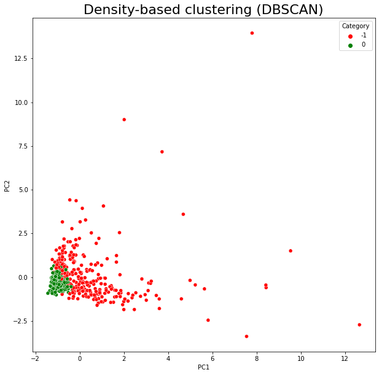

```python
db_clustering = DBSCAN(eps=0.5, min_samples=15).fit(trans_data)

db_data = reduced_data

# we notice only two category in this clustering
# 0 and -1. -1 represents noisy data.
db_data['Category'] = db_clustering.labels_

# showing first 10 rows of reduced_data with clustering labels
print(db_data.head(10))

# plotting PC1 vs PC2 to show clustering
figure = plt.figure(figsize = (10,10))
plot = figure.add_subplot(1,1,1)
sb.scatterplot(x = db_data['PC1'],y = db_data['PC2'],hue=db_data['Category'],palette=['r','g'])
plot.set_title('Density-based clustering (DBSCAN)', fontsize = 22)
```